**Last updated:** 2018-06-20

**workflowr checks:** (Click a bullet for more information)

- **✖** **R Markdown file:** uncommitted changes**

  The R Markdown is untracked by Git. To know which version of the R Markdown file created these results, you’ll want to first commit it to the Git repo. If you’re still working on the analysis, you can ignore this warning. When you’re finished, you can run `wflow_publish` to commit the R Markdown file and build the HTML.
- **✔** **Repository version:** d36f35f**

  Great! You are using Git for version control. Tracking code development and connecting the code version to the results is critical for reproducibility. The version displayed above was the version of the Git repository at the time these results were generated.  
  Note that you need to be careful to ensure that all relevant files for the analysis have been committed to Git prior to generating the results (you can use `wflow_publish` or `wflow_git_commit`). workflowr only checks the R Markdown file, but you know if there are other scripts or data files that it depends on. Below is the status of the Git repository when the results were generated:

  ```
  Ignored files:
      Ignored:    .DS_Store
      Ignored:    analysis/.DS_Store

  Untracked files:
      Untracked:  analysis/Batch-Effect-Part1.Rmd
  ```

  Note that any generated files, e.g. HTML, png, CSS, etc., are not included in this status report because it is ok for generated content to have uncommitted changes.

# Batch-Effect-Part1

Jesse Starkey

6/20/2018

load libraries and datasets

source(“http://bioconductor.org/biocLite.R”)

biocLite(“Biobase”)

biocLite(“genefilter”)

devtools::install_github(“genomicsclass/GSE5859”)

```r
library(Biobase)
library(rafalib)
library(genefilter)
library(GSE5859)
data(GSE5859)
```

# R markdown report 1

# gene expression levels

```r
geneExpression = exprs(e)
```

# print date info

```r
sampleInfo = pData(e)
head(sampleInfo$date)
```

```
## [1] "2003-02-04" "2003-02-04" "2002-12-17" "2003-01-30" "2003-01-03"
## [6] "2003-01-16"
```

# Output: print a table of year vs ethnic groups

```r
year = factor( format(sampleInfo$date,"%y") )
tab = table(year,sampleInfo$ethnicity)
print(tab)
```

```
##
## year ASN CEU HAN
##   02   0  32   0
##   03   0  54   0
##   04   0  13   0
##   05  80   3   0
##   06   2   0  24
```

# Differential expression analysis

## remove control genes

```r
out <- grep("AFFX",rownames(geneExpression))
```

# Use a t-test to perform differential expression analysis

# between CEU and ASN

```r
eth <- sampleInfo$ethnicity
ind<- which(eth%in%c("CEU","ASN"))
res1 <- rowttests(geneExpression[-out,ind],droplevels(eth[ind]))
```

# Use a t-test to perform differential expression analysis

# between 2002 vs 2003 within CEU

```r
ind <- which(year%in%c("02","03") & eth=="CEU")
res2 <- rowttests(geneExpression[-out,ind],droplevels(year[ind]))
```

# output: plot histograms for p-values

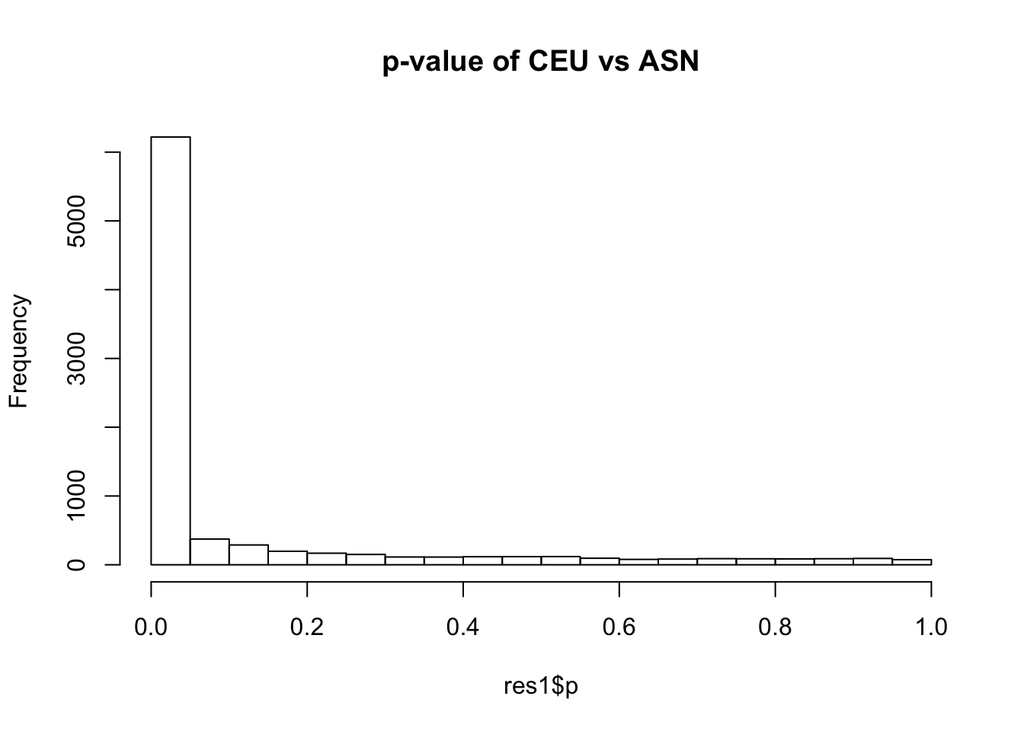

```r
hist(res1$p, main="p-value of CEU vs ASN")
```

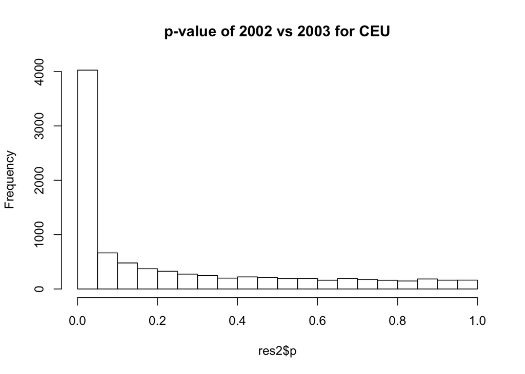

```r
hist(res2$p, main="p-value of 2002 vs 2003 for CEU")
```

This reproducible [R Markdown](http://rmarkdown.rstudio.com) analysis was created with workflowr 1.0.1